# Publication Figures – Reviewed

Maya Lapp

7/12/2021

Notes: in this file, the following labels are used for simulation dataframes: * `vallino` indicates data from the C&E model original code * `vallinoCorrected` indicates data from the corrected version of the C&E model (as described in the ODD framework) * `revised` indicates data from the M&S model (as described in the ODD framework) * no label (e.g. `allData`) indicates data from the M&S model with dynamic loggers

### Figure 4

Bravo single run

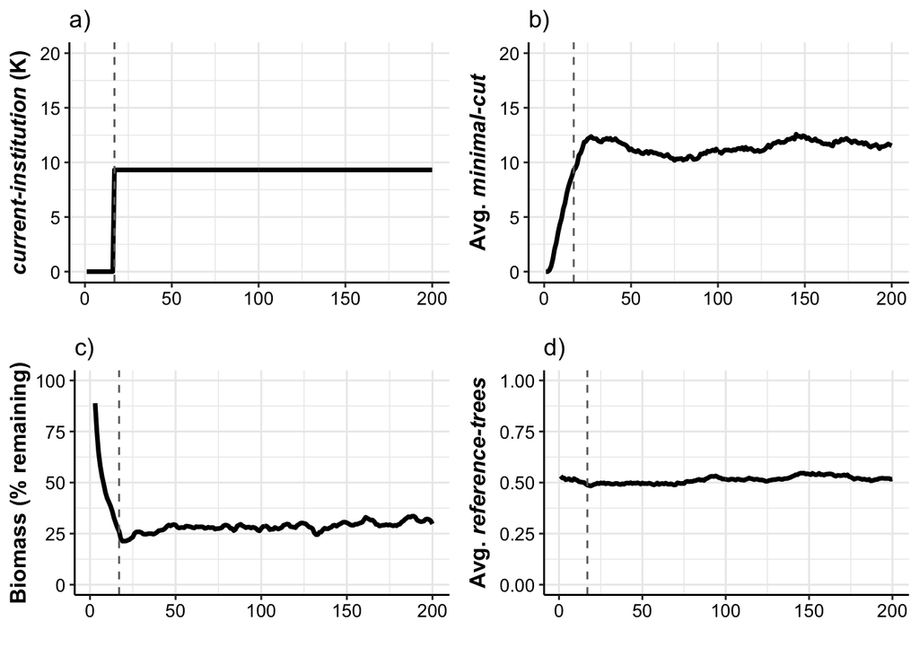

Check model steady state:

```
## [1] "Mean BM%: 0.311"
```

```
## [1] "SD BM%: 0.027"
```

## Original Vallino model analysis

### Figure 5

Minimal cut polarization - Bravo data

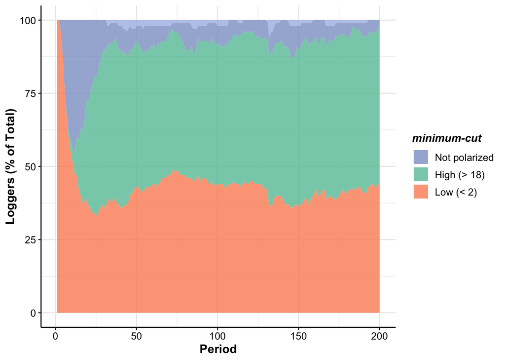

```
## [1] "Max Loggers older than 30 periods with medium MC: 6 %"
```

### Figure 6

Single run with tolerance-threshold = 1/3 bmax - the current-institution oscillates indefinitely parameters: endogenous institution, base parameters (bmax = 20), 100,000 ticks

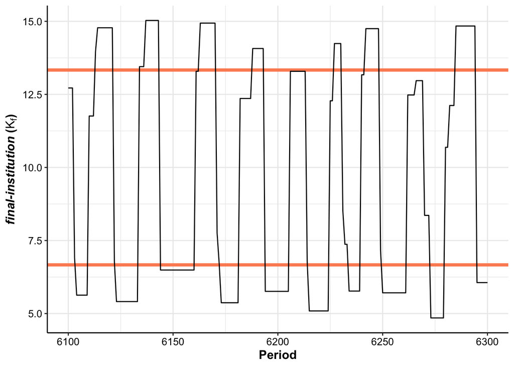

### Figure 7

Logger removal

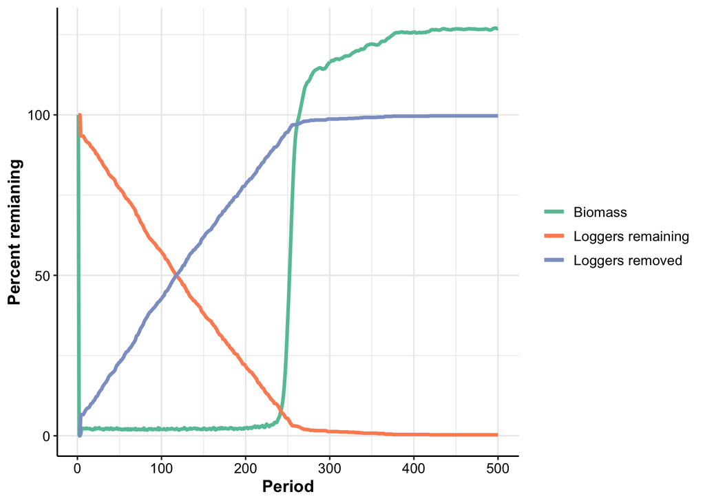

## C&E model corrected

Average BM for C&E corrected model

```
##   mean(TotalBM)
## 1      124.2553
```

### Figure 8

Number of loggers dominates BM% remaining

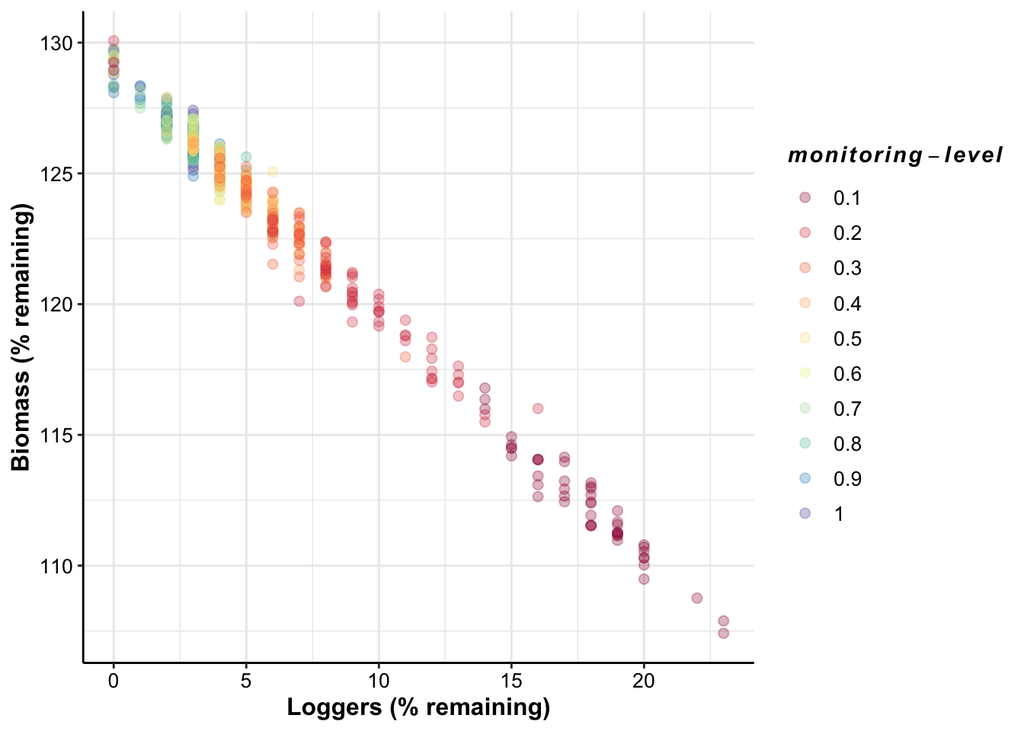

Regression As long as any Enforcement exists, Kf and monitoring-level do not significantly impact BM%

```
##
## Call:
## lm(formula = TotalBM * 100 ~ numLoggers + K + monLevel, data = vallinoCorrected_lm_data)
##
## Residuals:
##     Min      1Q  Median      3Q     Max
## -8.5232 -0.4881 -0.0171  0.4627  4.9597
##
## Coefficients:
##               Estimate Std. Error  t value Pr(>|t|)
## (Intercept)  128.97647    0.54001  238.839  < 2e-16 ***
## numLoggers  -108.01865    0.20899 -516.859  < 2e-16 ***
## K              0.15320    0.04558    3.361 0.000831 ***
## monLevel      -1.68163    0.18133   -9.274  < 2e-16 ***
## ---
## Signif. codes:  0 '***' 0.001 '**' 0.01 '*' 0.05 '.' 0.1 ' ' 1
##
## Residual standard error: 1.073 on 546 degrees of freedom
## Multiple R-squared:  0.9987, Adjusted R-squared:  0.9987
## F-statistic: 1.369e+05 on 3 and 546 DF,  p-value: < 2.2e-16
```

```
##
## Call:
## lm(formula = TotalBM * 100 ~ numLoggers + K + monLevel, data = vallinoCorrected_lm_data %>%
##     filter(anyEnf))
##
## Residuals:
##     Min      1Q  Median      3Q     Max
## -2.2646 -0.3317 -0.0176  0.3528  1.9500
##
## Coefficients:
##              Estimate Std. Error  t value Pr(>|t|)
## (Intercept) 128.60380    0.30206  425.755   <2e-16 ***
## numLoggers  -92.30220    0.76604 -120.492   <2e-16 ***
## K             0.01727    0.02324    0.743   0.4576
## monLevel      0.21046    0.12589    1.672   0.0952 .
## ---
## Signif. codes:  0 '***' 0.001 '**' 0.01 '*' 0.05 '.' 0.1 ' ' 1
##
## Residual standard error: 0.5183 on 496 degrees of freedom
## Multiple R-squared:  0.9866, Adjusted R-squared:  0.9865
## F-statistic: 1.219e+04 on 3 and 496 DF,  p-value: < 2.2e-16
```

## M&S model

### Figure 9

Kf and BM

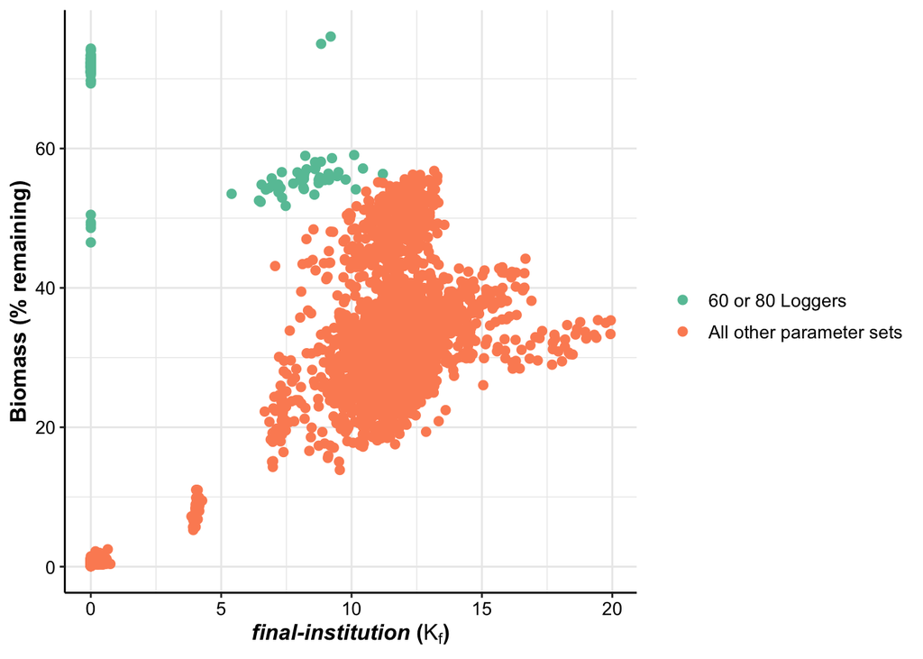

```
## [1] "Correlation for base data: 0.774"
```

```
## [1] "Correlation for all data: 0.736"
```

[output not shown]

### Figure 10

monitoring and sanctioning scatterplots, with mon/sanc = 0.2 and 0.8

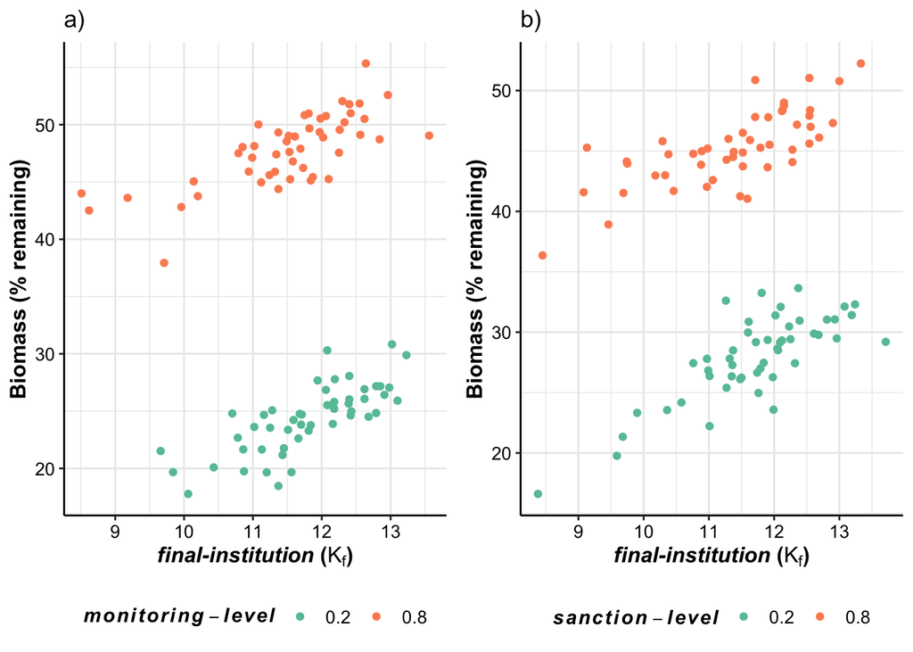

linear regressin models

```
##
## Call:
## lm(formula = TotalBM * 100 ~ K + monitoring + sanction, data = mon_sanc_data)
##
## Residuals:
##      Min       1Q   Median       3Q      Max
## -10.7572  -2.3192   0.1272   2.3513  10.4572
##
## Coefficients:
##             Estimate Std. Error t value Pr(>|t|)
## (Intercept) -19.4589     1.2376  -15.72   <2e-16 ***
## K             2.0768     0.1023   20.30   <2e-16 ***
## monitoring   34.1885     0.4519   75.65   <2e-16 ***
## sanction     27.5540     0.4522   60.94   <2e-16 ***
## ---
## Signif. codes:  0 '***' 0.001 '**' 0.01 '*' 0.05 '.' 0.1 ' ' 1
##
## Residual standard error: 3.352 on 1096 degrees of freedom
## Multiple R-squared:  0.899,  Adjusted R-squared:  0.8988
## F-statistic:  3253 on 3 and 1096 DF,  p-value: < 2.2e-16
```

### Figure 11

Dynamic Loggers M&S model reference-threshold and final-institution relationship scatterplot - with lines of best fit

reference-threshold scatterplot

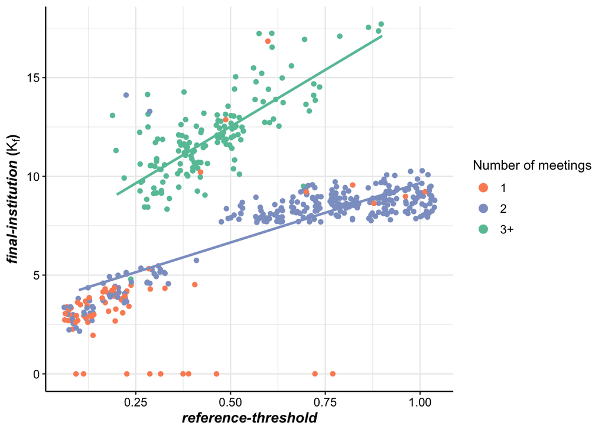